# Summarizing and exploring ontological results - generating benchmarks

# Introduction

This document provides a repex for all figures in the publication “Benchmarking Gene Ontology similarity methods and enabling their application”.

# Packages

Checkpoint for package reproducibility

```r
library(checkpoint)
checkpoint("2020-10-06")
```

```
## Using checkpoint directory /Users/qwm753/.checkpoint/2020-10-06/lib/x86_64-apple-darwin17.0/4.1.0
```

```r
#obviously local packages are not available on CRAN
# Error: Cannot install packages:
```

Anc2vec GO data is from 2020-10-06, (august 10th or november 6th?)

Rikens bioconductor has that version, https://bioconductor.riken.jp/packages/3.11/data/annotation/manuals/GO.db/man/GO.db.pdf

```r
library(org.Hs.eg.db)
library(parallel)
library(GO.db)
library(simplifyEnrichment)
```

```r
library(igraph)
library(ggplot2)
library(data.table)
library(patchwork)
library(dendextend)
library(ggsci)
library(ggraph)

theme_all <- theme_minimal() +
  theme(panel.border = element_rect(fill = NA),
        axis.ticks = element_line(),
        axis.text = element_text(size = 12, color = "black"),
        axis.title = element_text(size = 14, color = "black"))

source("functions.R")
```

# Distance metrics

## Anc2vec distances

```r
library(reticulate)
use_condaenv("anc2vec", required = T)
# reticulate::use_python("/Users/qwm753/opt/anaconda3/envs/anc2vec/bin/python")
```

```python
import anc2vec
import pandas as pd
from sklearn.metrics.pairwise import cosine_similarity
import numpy as np

emb = anc2vec.get_embeddings()

df_emb = pd.DataFrame.from_dict(emb)
df_emb.shape
```

```
## (200, 44261)
```

```python
df_emb = df_emb.transpose()

df_sim = cosine_similarity(df_emb)
df_sim = pd.DataFrame(df_sim, columns = df_emb.index.values)

exit
```

```
## Use exit() or Ctrl-D (i.e. EOF) to exit
```

```r
anc2vec_dist <- py$df_sim
rownames(anc2vec_dist) <- colnames(anc2vec_dist)
#save(anc2vec_dist, file = "data/anc2vec.Rdata")
#slower to save...
```

## Topology distance

Poor workaround, subsetting the available GO terms from anc2vec as its easier to do that rather than update anc2vec. If anc2vec has much higher performance i will revisit this.

```r
mf_graph <- graph_from_go("MF", colnames(anc2vec_dist))
bp_graph <- graph_from_go("BP", colnames(anc2vec_dist))
cc_graph <- graph_from_go("CC", colnames(anc2vec_dist))
```

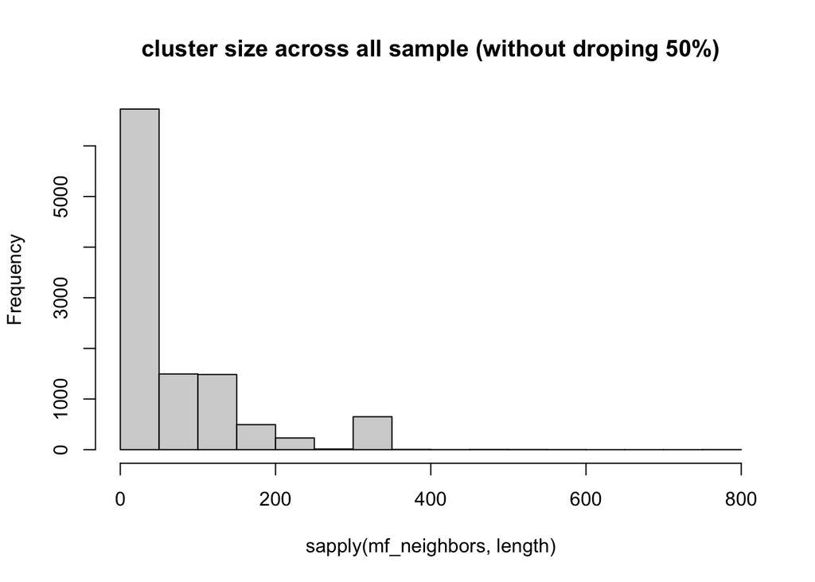

```r
mf_neighbors <- lapply(
  V(mf_graph)$name, \(x){
    neighborhood(mf_graph,
                 order = 2,
                 x)[[1]] |> as_ids()
  }
)
sapply(mf_neighbors, length) |> hist(main = 'cluster size across all sample (without droping 50%)')
```

```r
mf_neighbors <- mf_neighbors[sapply(mf_neighbors, length)<median(sapply(mf_neighbors, length))]
#retain only smaller than median for getting "realistic" cluster sizes
mf_neighbors <- mf_neighbors[sapply(mf_neighbors, length)>2]
# does 2 GO terms a cluster make?

mf_samples <- lapply(1:100, \(i){
  i <- sample(mf_neighbors, 10, replace = F)
  i <- sapply(i, \(ii){
    sample(ii, size = ceiling(length(ii) * .5))
  })
  i <- sapply(1:10,
              \(ii) structure(rep(ii, length(i[[ii]])), names = i[[ii]])) |>
    unlist()
  i <- i[!names(i) %in% names(i)[duplicated(names(i))]]
})
```

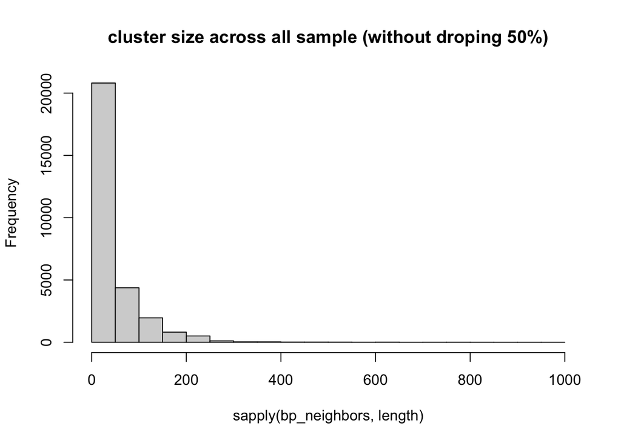

```r
bp_neighbors <- lapply(
  V(bp_graph)$name, \(x){
    neighborhood(bp_graph,
                 order = 2,
                 x)[[1]] |> as_ids()
  }
)
sapply(bp_neighbors, length) |> hist(main = 'cluster size across all sample (without droping 50%)')
```

```r
median(sapply(bp_neighbors, length))
```

```
## [1] 26
```

```r
bp_neighbors <- bp_neighbors[sapply(bp_neighbors, length)<median(sapply(bp_neighbors, length))]
bp_neighbors <- bp_neighbors[sapply(bp_neighbors, length)>2]

bp_samples <- lapply(1:100, \(i){
  i <- sample(bp_neighbors, 10, replace = F)
  i <- sapply(i, \(ii){
    sample(ii, size = ceiling(length(ii) * .5))
  })
  i <- sapply(1:10,
              \(ii) structure(rep(ii, length(i[[ii]])), names = i[[ii]])) |>
    unlist()
  i <- i[!names(i) %in% names(i)[duplicated(names(i))]]
})
#save for amazon running
#save(list = c("bp_samples", "bp_graph"), file = "bp_sample.Rdata")
```

## Reordering

```r
truth <- lapply(c("mf_samples", "bp_samples"), function(x){
  x <- get(x)
  lapply(x, function(i){
    i <- as.factor(i)
    levels(i) <- 1:length(levels(i))
    structure(as.numeric(i), names = names(i))
  })
})

names(truth) <- c("Geodesic MF", "Geodesic BP")
```

## Negative controls

```r
lies <- lapply(truth, \(dist){
  lapply(dist, \(n){
    structure(sample(n, replace = F),
              names = names(n))
  })
})
```

## Distance matrices

A small note on analysis not shown: tried to use the “information borrowing” effect of subsetting the graph in geodesic distance to the other clustering algorithms. Ie. in geodesic clustering the graph is subseted with targets and shortests paths between targets, giving more info to cluster. In the remaining methods this extra information is not included.

I tried including this (in geodesic shortest path terms), and it had no effect, if anything decreased the accuracy score. Wang takes too long, so that was excluded.

```r
mf <- unique(names(unlist(truth$`Geodesic MF`)))

all_dist_MF <- list(
  Wang = GO_similarity(mf,
                       "MF",
                       measure = "Wang"),
  Geodesic = distances(mf_graph),
  Resnik = GO_similarity(mf,
                         "MF",
                         measure = "Resnik"),
  Rel = GO_similarity(mf,
                      "MF",
                      measure = "Rel"),
  Jiang = GO_similarity(mf,
                        "MF",
                        measure = "Jiang"),
  Lin = GO_similarity(mf,
                      "MF",
                      measure = "Lin"),
  anc2vec = anc2vec_dist[mf, mf]
)

bp <- unique(names(unlist(truth$`Geodesic BP`)))

all_dist_BP <- list(
  Wang = GO_similarity(bp,
                       "BP",
                       measure = "Wang"),
  Geodesic = distances(bp_graph),
  Resnik = GO_similarity(bp,
                         "BP",
                         measure = "Resnik"),
  Rel = GO_similarity(bp,
                      "BP",
                      measure = "Rel"),
  Jiang = GO_similarity(bp,
                        "BP",
                        measure = "Jiang"),
  Lin = GO_similarity(bp,
                      "BP",
                      measure = "Lin"),
  anc2vec = anc2vec_dist[bp, bp]

)


all_dist_MF$anc2vec <- 1-as.matrix(all_dist_MF$anc2vec)
all_dist_MF$anc2vec[all_dist_MF$anc2vec<0] <- 0
all_dist_BP$anc2vec <- 1-as.matrix(all_dist_BP$anc2vec)
all_dist_BP$anc2vec[all_dist_BP$anc2vec<0] <- 0
```

Regarding negative cosine similarity, -1 is opposite, 0 is unlerated, 1 is same. Cosine distance can be defined as 1 - cosine similarity leading to a range of 0 - 2. This is perhaps not fully meaningful as it violates some [assumptions](https://en.wikipedia.org/wiki/Cosine_similarity#Definition)…

With that said there is something suspicious here: 1-cosine distance is giving very small negative, ie cosine sim has values above 1. Also, looking at the pd sklearn_cosine_similarity and the np sklearn_cosine_similarity have tiny rounding errors to them…

# Grid search on Geodesic benchmark

Binary cut does not converge. MCL converges on all methods except the IC methods, and has really poor accuracy (not shown).

```
## [1] "Geodesic distance clustered with leiden"
## [1] "----------------"
## [1] "Geodesic distance clustered with fast_greedy"
## [1] "----------------"
## [1] "Geodesic distance clustered with louvain"
## [1] "----------------"
## [1] "Geodesic distance clustered with walktrap"
## [1] "----------------"
## [1] "Geodesic distance clustered with leading_eigen"
## [1] "----------------"
## [1] "Geodesic distance clustered with mclust"
## [1] "----------------"
## [1] "Geodesic distance clustered with dynamicTreeCut"
## [1] "----------------"
## [1] "Geodesic distance clustered with apcluster"
```

[output cut: 125 more lines]

```
## [1] "Geodesic distance clustered with leiden"
## [1] "----------------"
## [1] "Geodesic distance clustered with fast_greedy"
## [1] "----------------"
## [1] "Geodesic distance clustered with louvain"
## [1] "----------------"
## [1] "Geodesic distance clustered with walktrap"
## [1] "----------------"
## [1] "Geodesic distance clustered with leading_eigen"
## [1] "----------------"
## [1] "Geodesic distance clustered with mclust"
## [1] "----------------"
## [1] "Geodesic distance clustered with dynamicTreeCut"
## [1] "----------------"
## [1] "Geodesic distance clustered with apcluster"
```

[output cut: 125 more lines]

```
## [1] "Geodesic distance clustered with leiden"
## [1] "----------------"
## [1] "Geodesic distance clustered with fast_greedy"
## [1] "----------------"
## [1] "Geodesic distance clustered with louvain"
## [1] "----------------"
## [1] "Geodesic distance clustered with walktrap"
## [1] "----------------"
## [1] "Geodesic distance clustered with leading_eigen"
## [1] "----------------"
## [1] "Geodesic distance clustered with mclust"
## [1] "----------------"
## [1] "Geodesic distance clustered with dynamicTreeCut"
## [1] "----------------"
## [1] "Geodesic distance clustered with apcluster"
```

[output cut: 125 more lines]

Did they all converge?

```r
sapply(predictions_topology_MF, \(d){
  sapply(d, \(cl){
    sum(sapply(cl, is.null))
  })
})
```

```
##                Geodesic Wang Resnik Rel Jiang Lin anc2vec
## leiden                0    0      0   0     0   0       0
## fast_greedy           0    0      0   0     0   0       0
## louvain               0    0      0   0     0   0       0
## walktrap              0    0      0   0     0   0       0
## leading_eigen         0    0      0   0     1   0       0
## mclust                0    0      0   0     0   0       0
## dynamicTreeCut        0    0      0   0     0   0       0
## apcluster             0    0      0   0     0   0       0
## hdbscan               0    0      0   0     0   0       0
## kmeans                0    0      0   0     0   0       0
```

```r
sapply(predictions_topology_BP, \(d){
  sapply(d, \(cl){
    sum(sapply(cl, is.null))
  })
})
```

```
##                Geodesic Wang Resnik Rel Jiang Lin anc2vec
## leiden                0    0      0   0     0   0       0
## fast_greedy           0    0      0   0     0   0       0
## louvain               0    0      0   0     0   0       0
## walktrap              0    0      0   0     0   0       0
## leading_eigen         0    0      0   0     0   0       0
## mclust                0    0      0   0     0   0       2
## dynamicTreeCut        0    0      0   0     0   0       0
## apcluster             0    0      0   0     0   0       0
## hdbscan               0    0      0   0     0   0       0
## kmeans                0    0      0   0     0   0       0
```

Dropping all that are not “data.frame”.

```r
predictions_topology_MF <- lapply(predictions_topology_MF, \(d){
  d <- lapply(d, \(cl){
    cl[sapply(cl, class) == "data.frame"]
  })
  d[sapply(d, length)>0]
})
predictions_neg_topology_MF <- lapply(predictions_neg_topology_MF, \(d){
  d <- lapply(d, \(cl){
    cl[sapply(cl, class) == "data.frame"]
  })
  d[sapply(d, length)>0]
})
predictions_topology_BP <- lapply(predictions_topology_BP, \(d){
  d <- lapply(d, \(cl){
    cl[sapply(cl, class) == "data.frame"]
  })
  d[sapply(d, length)>0]
})
```

# Evaluating

## Accuracy - Fowlkes–Mallows index

Reshaping

```r
predictions_topology_MF <- reshape2::melt(
  predictions_topology_MF,
  id.vars=c("ID", "prediction", "truth")) |>
  as.data.table()

predictions_topology_BP <- reshape2::melt(
  predictions_topology_BP,
  id.vars=c("ID", "prediction", "truth")) |>
  as.data.table()

predictions_neg_topology_MF <- reshape2::melt(
  predictions_neg_topology_MF,
  id.vars=c("ID", "prediction", "truth")) |>
  as.data.table()
```

Ordering and colors for subsequent graphs

```r
distance_order <- c("Geodesic", "Wang", "anc2vec", "Resnik",
                    "Rel", "Jiang", "Lin")

cluster_order <- c("leiden", "fast_greedy", "louvain", "walktrap",
                   "leading_eigen", "mclust", "DTC",
                   "apcluster", "hdbscan", "kmeans")

predictions_topology_MF$L2 <- gsub("dynamicTreeCut","DTC",
                                   predictions_topology_MF$L2)
predictions_topology_MF$L2 <- factor(predictions_topology_MF$L2,
                                     levels = cluster_order)

predictions_topology_BP$L2 <- gsub("dynamicTreeCut","DTC",
                                   predictions_topology_BP$L2)
predictions_topology_BP$L2 <- factor(predictions_topology_BP$L2,
                                     levels = cluster_order)

predictions_neg_topology_MF$L2 <- gsub("dynamicTreeCut","DTC",
                                       predictions_neg_topology_MF$L2)
predictions_neg_topology_MF$L2 <- factor(predictions_neg_topology_MF$L2,
                                         levels = cluster_order)
```

### Heatmap

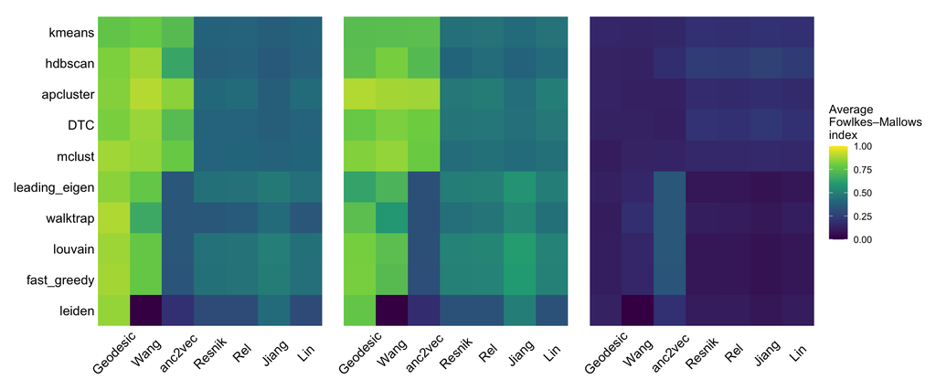

```r
predictions_topology_MF[,mean(fm(.SD)), by=c("L1", "L2", "L3")][,mean(V1), by = c("L1", "L2")] |>
  ggplot(aes(x = L1, y = L2, fill = V1)) +
  geom_tile() +
  xlab("Distance metric") +
  ylab('Cluster method') +
  scale_fill_viridis_c(name = "Average\nFowlkes–Mallows\nindex",
                       limits = c(0,1)) +
  scale_x_discrete(limits=distance_order) +
  scale_y_discrete(limits=cluster_order) +
  theme_void() +
  theme(panel.border = element_blank(),
        axis.ticks = element_blank(),
        axis.text.y = element_text(size = 12, hjust = 1, color = "black"),
        axis.text.x = element_text(size = 12, hjust = 0.5, angle = 45, color = "black"),
        plot.margin = margin(0.25,0.25,0.25,0.25, unit = "cm")) +

  predictions_topology_BP[,mean(fm(.SD)), by=c("L1", "L2", "L3")][,mean(V1), by = c("L1", "L2")] |>
  ggplot(aes(x = L1, y = L2, fill = V1)) +
  geom_tile() +
  xlab("Distance metric") +
  ylab('Cluster method') +
  scale_fill_viridis_c(name = "Average\nFowlkes–Mallows\nindex",
                       limits = c(0,1)) +
  scale_x_discrete(limits=distance_order) +
  scale_y_discrete(limits=cluster_order) +
  theme_void() +
  theme(panel.border = element_blank(),
        axis.ticks = element_blank(),
        axis.text.x = element_text(size = 12, hjust = 0.5,  angle = 45, color = "black"),
        plot.margin = margin(0.25,0.25,0.25,0.25, unit = "cm")) +

  predictions_neg_topology_MF[,mean(fm(.SD)), by=c("L1", "L2", "L3")][,mean(V1), by = c("L1", "L2")] |>
  ggplot(aes(x = L1, y = L2, fill = V1)) +
  geom_tile() +
  xlab("Distance metric") +
  ylab('Cluster method') +
  scale_fill_viridis_c(name = "Average\nFowlkes–Mallows\nindex",
                       limits = c(0,1), na.value = 0) +
  scale_x_discrete(limits=distance_order) +
  scale_y_discrete(limits=cluster_order) +
  theme_void() +
  theme(panel.border = element_blank(),
        axis.ticks = element_blank(),
        axis.text.x = element_text(size = 12, hjust = 0.5, angle = 45, color = "black"),
        plot.margin = margin(0.25,0.25,0.25,0.25, unit = "cm")) +

  plot_layout(guides = "collect")
```

### Boxplot

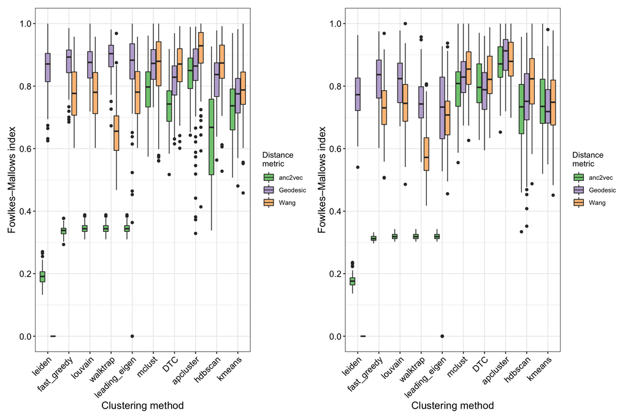

```r
predictions_topology_MF[,fm(.SD), by=c("L1", "L2", "L3")][L1 %in% c("Geodesic", "Wang", "anc2vec")] |>
  ggplot(aes(x = L2, fill = L1, y = V1)) +
  geom_boxplot() +
  scale_x_discrete(limits = cluster_order) +
  scale_y_continuous(breaks = seq(0, 1, .2)) +
  scale_fill_brewer(type = "qual", palette = 1) +
  theme_all +
  xlab("Clustering method") +
  ylab('Fowlkes–Mallows index') +
  guides(fill = guide_legend(title = "Distance\nmetric")) +

  predictions_topology_BP[,fm(.SD), by=c("L1", "L2", "L3")][L1 %in% c("Geodesic", "Wang", "anc2vec")] |>
  ggplot(aes(x = L2, fill = L1, y = V1)) +
  geom_boxplot() +
  scale_x_discrete(limits = cluster_order) +
  scale_y_continuous(breaks = seq(0, 1, .2)) +
  scale_fill_brewer(type = "qual", palette = 1) +
  theme_all +
  xlab("Clustering method") +
  ylab('Fowlkes–Mallows index') +
  guides(fill = guide_legend(title = "Distance\nmetric")) &

  plot_layout(guides = "collect") &
  theme(axis.text.x.bottom = element_text(angle=45, vjust = 1, hjust = 1))
```

### Size and length

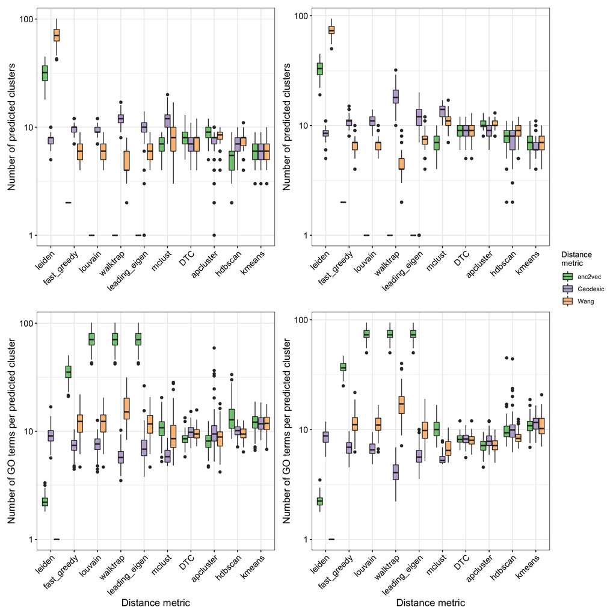

```r
predictions_topology_MF[,length(unique(.SD$prediction)), by=c("L1", "L2", "L3")][L1 %in% c("Geodesic", "Wang", "anc2vec")]  |>
  ggplot(aes(x = L2, fill = L1, y = V1)) +
  xlab("") +
  ylab('Number of predicted clusters') +

  predictions_topology_BP[,length(unique(.SD$prediction)), by=c("L1", "L2", "L3")][L1 %in% c("Geodesic", "Wang", "anc2vec")] |>
  ggplot(mapping = aes(x = L2, fill = L1, y = V1)) +
  xlab("") +
  ylab('Number of predicted clusters') +

  predictions_topology_MF[,mean(table(.SD$prediction)), by=c("L1", "L2", "L3")][L1 %in% c("Geodesic", "Wang", "anc2vec")]  |>
  ggplot(aes(x = L2, fill = L1, y = V1)) +
  xlab("Distance metric") +
  ylab('Number of GO terms per predicted cluster') +

  predictions_topology_BP[,mean(table(.SD$prediction)), by=c("L1", "L2", "L3")][L1 %in% c("Geodesic", "Wang", "anc2vec")]  |>
  ggplot(aes(x = L2, fill = L1, y = V1)) +
  xlab("Distance metric") +
  ylab('Number of GO terms per predicted cluster') +

  plot_layout(guides = 'collect', ncol = 2) &
  guides(fill = guide_legend(title = "Distance\nmetric")) &
  scale_y_log10() &
  geom_boxplot() &
  scale_x_discrete(limits = cluster_order) &
  theme_all &
  theme(axis.text.x.bottom = element_text(angle=45, vjust = 1, hjust = 1)) &
  scale_fill_brewer(type = "qual")
```

## GO tree visualization

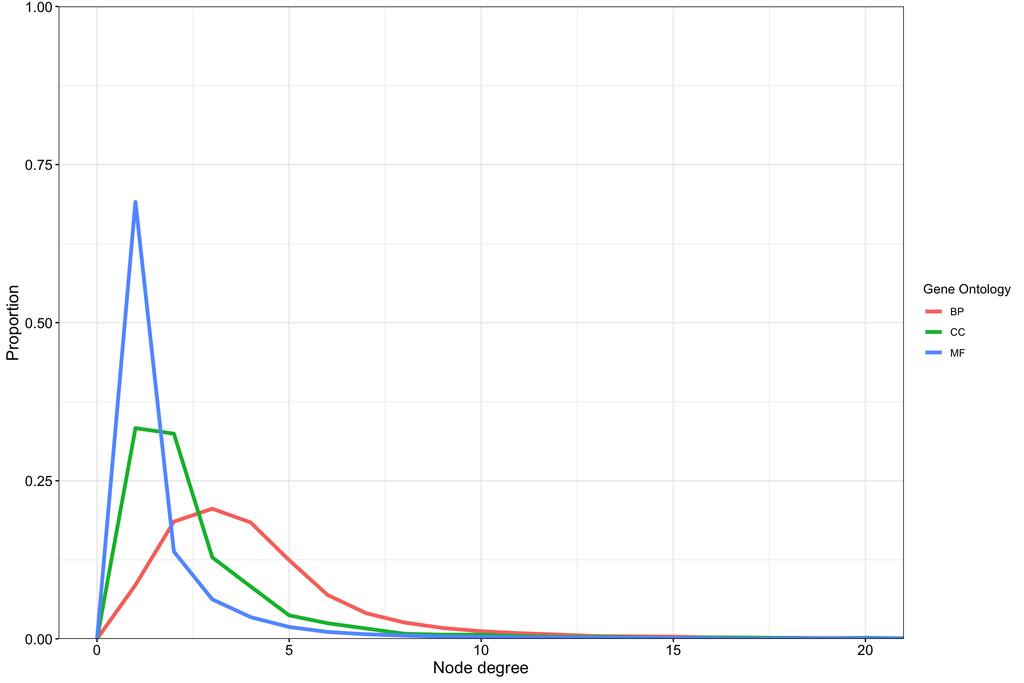

```r
GO_structure <- rbind(
  data.frame(Proportion = degree_distribution(bp_graph),
             graph = "BP",
             Degree = 0:(length(degree_distribution(bp_graph))-1)),
  data.frame(Proportion = degree_distribution(mf_graph),
             graph = "MF",
             Degree = 0:(length(degree_distribution(mf_graph))-1)),
  data.frame(Proportion = degree_distribution(cc_graph),
             graph = "CC",
             Degree = 0:(length(degree_distribution(cc_graph))-1))
)

ggplot(data = GO_structure,
       mapping = aes(x=Degree, y = Proportion, color = graph)) +
  geom_line(lwd = 1.5) +
  coord_cartesian(xlim = c(0,20), ylim = c(0, 1)) +
  scale_y_continuous(expand = c(0,0)) +
  scale_color_discrete(name = "Gene Ontology") +
  xlab("Node degree") +
  theme_all
```

## Sample visualization

### Cluster size

Visualize number of GO terms per sample, number of clusters per sample,

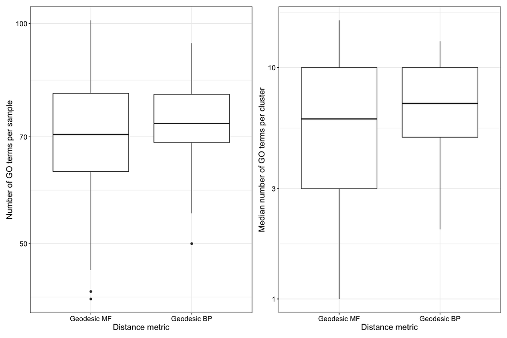

```r
sample_size_plot <- sapply(truth, \(x) sapply(x, \(xx) length(xx))) |> reshape2::melt()
cluster_size_plot <- sapply(truth, \(x) sapply(x, \(xx) as.numeric(table(xx)))) |> reshape2::melt()#fix this!

ggplot(sample_size_plot, aes(x = Var2, y = value)) +
  geom_boxplot() +
  ylab("Number of GO terms per sample") +
  xlab("Distance metric") +
  scale_y_log10() +
  theme_all +
  ggplot(cluster_size_plot, aes(x = Var2, y = value)) +
  geom_boxplot() +
  ylab("Median number of GO terms per cluster") +
  xlab("Distance metric") +
  scale_y_log10() +
  theme_all
```

### Cluster title diversity

GO ids to titles

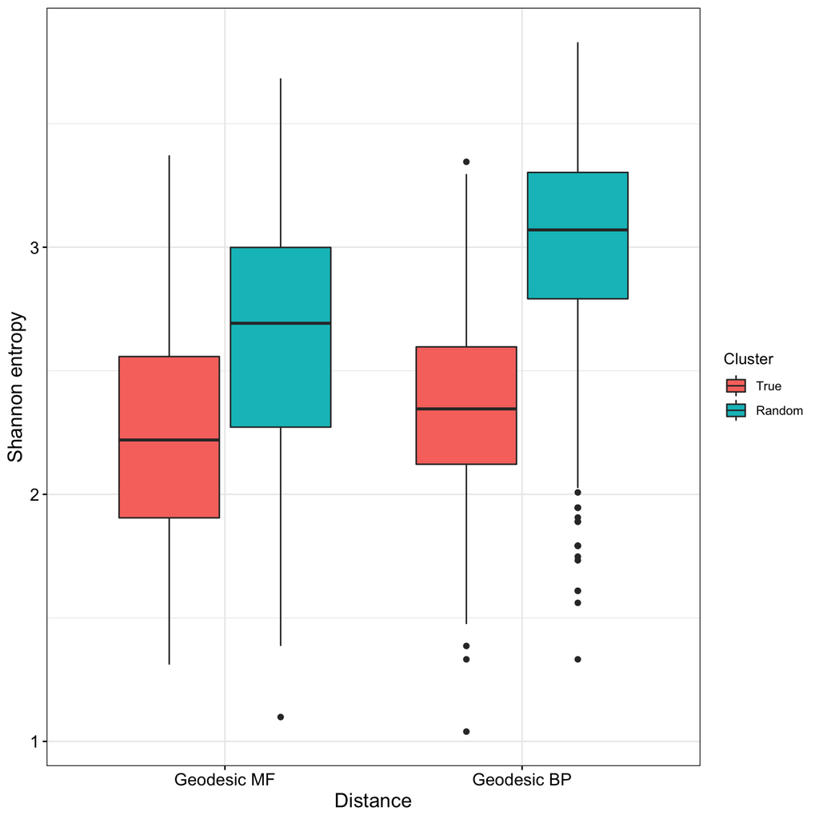

### Cluster examples

For table 1.

```r
lapply(1:3, \(i){
 go_titles[truth$`Geodesic MF`[[1]][truth$`Geodesic MF`[[1]] == i] |> names()] |> as.character()
})
```

```
## [[1]]
## [1] "glyceryl-ether monooxygenase activity"
## [2] "phenylalanine 4-monooxygenase activity"
## [3] "tryptophan 5-monooxygenase activity"
## [4] "phenylalanine 4-hydroxylase (N10-formyl-tetrahydrofolate dependent) activity"
##
## [[2]]
## [1] "oxidoreductase activity, acting on the CH-CH group of donors"
## [2] "3-oxo-5-alpha-steroid 4-dehydrogenase activity"
## [3] "steroid dehydrogenase activity"
##
## [[3]]
## [1] "beta-galactoside alpha-2,3-sialyltransferase activity"
## [2] "neolactotetraosylceramide alpha-2,3-sialyltransferase activity"
## [3] "lactosylceramide alpha-2,6-N-sialyltransferase activity"
## [4] "alpha-N-acetylneuraminate alpha-2,8-sialyltransferase activity"
## [5] "N-acetyllactosaminide alpha-2,3-sialyltransferase activity"
## [6] "(alpha-N-acetylneuraminyl-2,3-beta-galactosyl-1,3)-N-acetyl-galactosaminide 6-alpha-sialyltransferase activity"
## [7] "sialyltransferase activity"
```

```r
lapply(1:5, \(i){
 go_titles[truth$`Geodesic BP`[[1]][truth$`Geodesic MF`[[1]] == i] |> names()] |> as.character()
})
```

```
## [[1]]
## [1] "limb development"
## [2] "limb morphogenesis"
## [3] "post-embryonic pelvic fin morphogenesis"
## [4] "post-embryonic forelimb morphogenesis"
## [5] "spindle assembly involved in male meiosis II"
## [6] "spindle assembly"
## [7] "anastral spindle assembly involved in male meiosis"
## [8] "selenate transport"
##
## [[2]]
## [1] "embryonic limb morphogenesis"
## [2] "hindlimb morphogenesis"
## [3] "post-embryonic hindlimb morphogenesis"
## [4] "inorganic anion transport"
```

[output cut: 50 more lines]

# Figures

## Size and figure size

```r
A4_height <- 11.75
A4_width <- 8.25

theme_figures <- theme_minimal() +
  theme(panel.border = element_rect(fill = NA),
        axis.ticks = element_line(),
        axis.text = element_text(size = 8, color = "black"),
        axis.title = element_text(size = 9, color = "black"),
        legend.title = element_text(size = 8, color = "black"))
```

## Schematic of cluster generation

```r
g_all <- subgraph(mf_graph,
              c(neighborhood(mf_graph, 2, "GO:0016209")[[1]],
                neighborhood(mf_graph, 2, "GO:0003674")[[1]]))

#delete some for looks only!
g_all <- delete.vertices(g_all, c("GO:0072541", "GO:0033196"))
#common fig1
V(g_all)$size <- .25
V(g_all)$color <- "#DBA237"

g <- create_layout(g_all, layout = 'nicely')

#before selection
g1 <- ggraph(g) +
  geom_edge_link(color = "gray", width = .25) +
  geom_node_point(color = g$color, size = g$size) +
  theme_void()

#select random
s <- "GO:0016684"
g$color[g$name %in% s] <- "red"
g$size[g$name == s] <- 2

g2 <- ggraph(g) +
  geom_edge_link(color = "gray", size = 10, width = .25) +
  geom_node_point(color = g$color, size = g$size) +
  theme_void()
#show sample first
ss <- as_ids(neighborhood(g_all, 2, s)[[1]])
g$size[g$name == ss] <- 1
g$color[g$name %in% ss] <- "blue"
g$color[g$name %in% s] <- "red"
g3 <- ggraph(g) +
  geom_edge_link(color = "gray", width = .25) +
  geom_node_point(color = g$color, size = g$size) +
  theme_void()

#select half

g$color[g$name %in% sample(ss, length(ss)*.5)] <- "gray"
g$color[g$name %in% s] <- "red"

g4 <- ggraph(g) +
  geom_edge_link(color = "gray", width = .25) +
  geom_node_point(color = g$color, size = g$size) +
  theme_void()
```

## F1

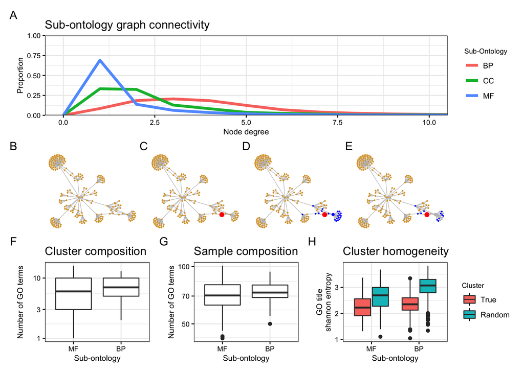

```r
(
  ggplot(data = GO_structure,
         mapping = aes(x=Degree, y = Proportion, color = graph)) +
    geom_line(lwd = 1.5) +
    coord_cartesian(xlim = c(0,10), ylim = c(0, 1)) +
    scale_y_continuous(expand = c(0,0)) +
    scale_color_discrete(name = "Sub-Ontology") +
    xlab("Node degree") +
    ggtitle("Sub-ontology graph connectivity") +
    theme_figures
) / (
  g1 + g2 + g3 + g4 +
    plot_layout(ncol = 4)
) / (
  ggplot(cluster_size_plot, aes(x = Var2, y = value)) +
    geom_boxplot() +
    ylab("Number of GO terms") +
    ggtitle("Cluster composition") +
    scale_y_log10() +

    ggplot(sample_size_plot, aes(x = Var2, y = value)) +
    geom_boxplot() +
    ylab("Number of GO terms") +
    ggtitle("Sample composition") +
    scale_y_log10() +

    ggplot(title_diversity, aes(x = Distance, fill = Cluster, y = value)) +
    geom_boxplot() +
    ylab("GO title\nshannon entropy") +
    ggtitle("Cluster homogeneity") &

    theme_figures &
    scale_x_discrete(labels = c("MF", "BP")) &
    xlab("Sub-ontology")
  ) &
  plot_annotation(tag_levels = "A")
```

```r
ggsave(filename = "figures/F1.pdf",
       width = A4_width,
       height = A4_height*.5)
```

## F2

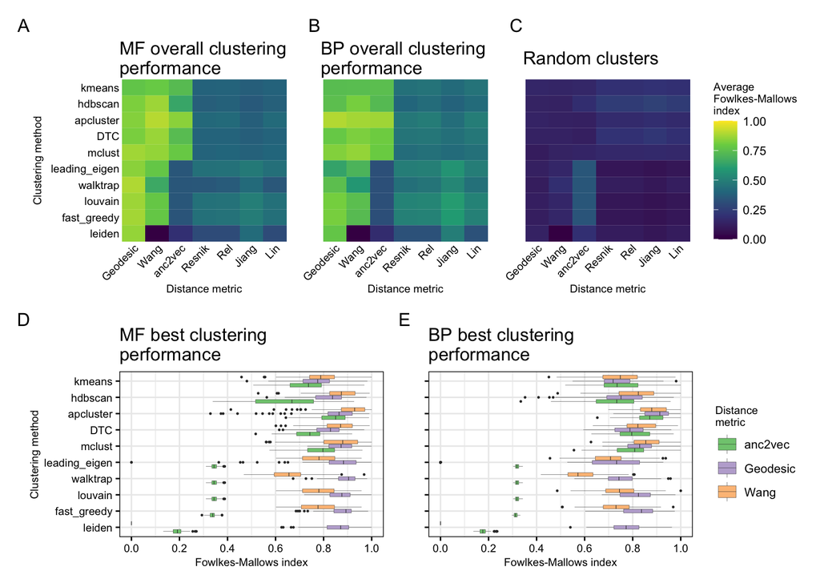

```r
(
  predictions_topology_MF[,mean(fm(.SD)), by=c("L1", "L2", "L3")][,mean(V1), by = c("L1", "L2")] |>
    ggplot(aes(x = L1, y = L2, fill = V1)) +
    geom_tile() +
    xlab("Distance metric") +
    ylab("Clustering method") +
    ggtitle("MF overall clustering\nperformance") +
    scale_fill_viridis_c(name = "Average\nFowlkes-Mallows\nindex",
                         limits = c(0,1)) +
    scale_x_discrete(limits=distance_order) +
    scale_y_discrete(limits=cluster_order) +
    theme_void() +
    theme(axis.text.x = element_text(size = 8, angle = 45, vjust = 1, hjust = 1, color = "black"),
        axis.text.y.left = element_text(size = 8, hjust = 1, color = "black"),
        axis.title.y = element_text(size = 8, angle = 90),
        axis.title.x = element_text(size = 8),
        plot.margin = margin(0.25,0.25,0.25,0.25, unit = "cm"),
        legend.title = element_text(size = 8)) +


    predictions_topology_BP[,mean(fm(.SD)), by=c("L1", "L2", "L3")][,mean(V1), by = c("L1", "L2")] |>
    ggplot(aes(x = L1, y = L2, fill = V1)) +
    geom_tile() +
    xlab("Distance metric") +
    ggtitle("BP overall clustering\nperformance") +
    scale_fill_viridis_c(name = "Average\nFowlkes-Mallows\nindex",
                         limits = c(0,1)) +
    scale_x_discrete(limits=distance_order) +
    scale_y_discrete(limits=cluster_order) +
    theme_void() +
    theme(axis.text.x = element_text(size = 8, angle = 45, vjust = 1, hjust = 1, color = "black"),
          axis.title.x = element_text(size = 8),
          axis.text.y.left = element_blank(),
          axis.title.y =  element_blank(),
          plot.margin = margin(0.25,0.25,0.25,0.25, unit = "cm"),
          legend.title = element_text(size = 8)) +

    predictions_neg_topology_MF[,mean(fm(.SD)), by=c("L1", "L2", "L3")][,mean(V1), by = c("L1", "L2")] |>
    ggplot(aes(x = L1, y = L2, fill = V1)) +
    geom_tile() +
    xlab("Distance metric") +
    ggtitle("Random clusters") +
    scale_fill_viridis_c(name = "Average\nFowlkes-Mallows\nindex",
                         limits = c(0,1), na.value = 0) +
    scale_x_discrete(limits=distance_order) +
    scale_y_discrete(limits=cluster_order) +
    theme_void() +
    theme(axis.text.x = element_text(size = 8, angle = 45, vjust = 1, hjust = 1, color = "black"),
          axis.title.x = element_text(size = 8),
          axis.text.y.left = element_blank(),
          axis.title.y =  element_blank(),
          plot.margin = margin(0.25,0.25,0.25,0.25, unit = "cm"),
          legend.title = element_text(size = 8)) +
    plot_layout(guides = "collect")
) / (
  predictions_topology_MF[,fm(.SD), by=c("L1", "L2", "L3")][L1 %in% c("Geodesic", "Wang", "anc2vec")] |>
    ggplot(aes(x = V1,y = L2, fill = L1)) +
    geom_boxplot(outlier.size = .25, lwd = .1) +
    scale_y_discrete(limits = cluster_order) +
    scale_x_continuous(breaks = seq(0, 1, .2)) +
    scale_fill_brewer(type = "qual", palette = 1) +
    theme_figures +
    theme(axis.text = element_text(size = 8),
          axis.title = element_text(size = 8),
          legend.title = element_text(size = 8)) +
    ylab("Clustering method") +
    xlab('Fowlkes-Mallows index') +
    ggtitle("MF best clustering\nperformance") +
    guides(fill = guide_legend(title = "Distance\nmetric")) +

    predictions_topology_BP[,fm(.SD), by=c("L1", "L2", "L3")][L1 %in% c("Geodesic", "Wang", "anc2vec")] |>
    ggplot(aes(x = V1,y = L2, fill = L1)) +
    geom_boxplot(outlier.size = .25, lwd = .1) +
    scale_y_discrete(limits = cluster_order) +
    scale_x_continuous(breaks = seq(0, 1, .2)) +
    scale_fill_brewer(type = "qual", palette = 1) +
    theme_figures +
    theme(axis.text = element_text(size = 8),
          axis.title = element_text(size = 8),
          axis.text.y.left = element_blank(),
          legend.title = element_text(size = 8)) +
    ylab("") +
    xlab('Fowlkes-Mallows index') +
    ggtitle("BP best clustering\nperformance") +
  guides(fill = guide_legend(title = "Distance\nmetric")) +
    plot_layout(guides = "collect")
) &
  plot_annotation(tag_levels = "A")
```

```r
ggsave(filename = "figures/F2.pdf",
       width = A4_width,
       height = A4_height/2)
```

## F3

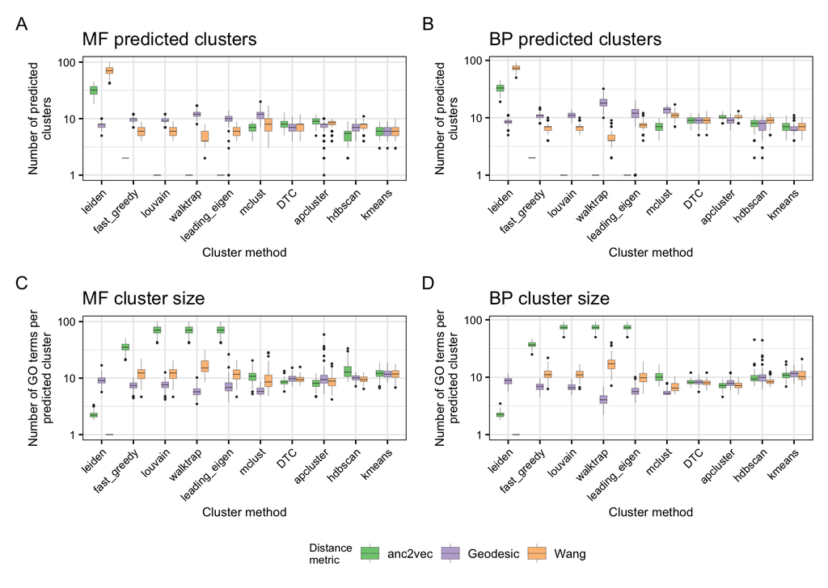

```r
predictions_topology_MF[,length(unique(.SD$prediction)), by=c("L1", "L2", "L3")][L1 %in% c("Geodesic", "Wang", "anc2vec")]  |>
  ggplot(aes(x = L2, fill = L1, y = V1)) +
  xlab("Cluster method") +
  ylab('Number of predicted\nclusters') +
  ggtitle("MF predicted clusters") +

  predictions_topology_BP[,length(unique(.SD$prediction)), by=c("L1", "L2", "L3")][L1 %in% c("Geodesic", "Wang", "anc2vec")] |>
  ggplot(mapping = aes(x = L2, fill = L1, y = V1)) +
  xlab("Cluster method") +
  ylab('Number of predicted\nclusters') +
  ggtitle("BP predicted clusters") +

  predictions_topology_MF[,mean(table(.SD$prediction)), by=c("L1", "L2", "L3")][L1 %in% c("Geodesic", "Wang", "anc2vec")]  |>
  ggplot(aes(x = L2, fill = L1, y = V1)) +
  xlab("Cluster method") +
  ylab('Number of GO terms per\npredicted cluster') +
  ggtitle("MF cluster size") +

  predictions_topology_BP[,mean(table(.SD$prediction)), by=c("L1", "L2", "L3")][L1 %in% c("Geodesic", "Wang", "anc2vec")]  |>
  ggplot(aes(x = L2, fill = L1, y = V1)) +
  xlab("Cluster method") +
  ylab('Number of GO terms per\npredicted cluster') +
  ggtitle("BP cluster size") +

  plot_layout(guides = 'collect', ncol = 2) &
  plot_annotation(tag_levels = "A") &

  guides(fill = guide_legend(title = "Distance\nmetric")) &
  scale_y_log10() &
  geom_boxplot(outlier.size = .25, lwd = .1) &
  scale_x_discrete(limits = cluster_order) &
  theme_figures &
  theme(axis.text.x.bottom = element_text(angle = 45,
                                          hjust = 1),
        legend.position = "bottom") &
  scale_fill_brewer(type = "qual")
```

```r
ggsave(filename = "figures/F3.pdf",
       width = A4_width,
       height = A4_height*.5)
```

## Data for F4

Generating GO terms using GSEA to use as a case study in ontodesc

```r
################################################################
#Differential expression and camera analysis
library(GEOquery)
library(limma)
# load series and platform data from GEO

gset <- getGEO("GSE31803",GSEMatrix =TRUE, getGPL=TRUE, AnnotGPL=TRUE, destdir = "./data/")
```

```
## Found 2 file(s)
```

```
## GSE31803-GPL13534_series_matrix.txt.gz
```

```
## Using locally cached version: ./data//GSE31803-GPL13534_series_matrix.txt.gz
```

```
## Annotation GPL not available, so will use submitter GPL instead
## Using locally cached version of GPL13534 found here:
## ./data//GPL13534.soft
```

```
## GSE31803-GPL570_series_matrix.txt.gz
## Using locally cached version: ./data//GSE31803-GPL570_series_matrix.txt.gz
## ./data//GPL570.annot.gz
```

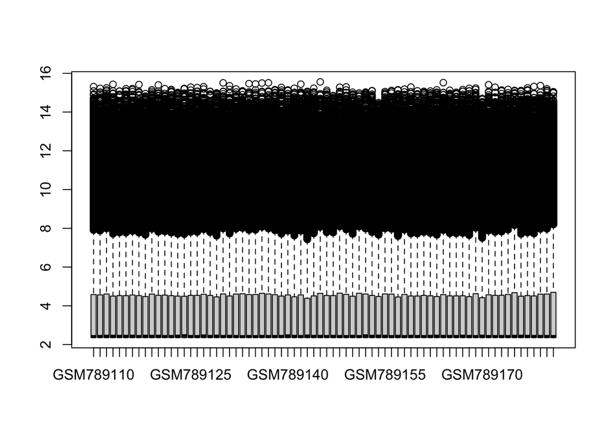

```r
gset <- gset$`GSE31803-GPL570_series_matrix.txt.gz` #the other gpl is a methylation
pdata <- gset@phenoData@data # make proper column names to match toptable
colnames(pdata) <- make.names(colnames(pdata))
pdata$liver <- as.factor(pdata$Stage.ch1)
levels(pdata$liver) <- c("advanced", "mild")

# fix feature data
fdata <- gset@featureData@data[,c("Gene symbol", "Gene ID")]
colnames(fdata) <- c("SYMBOL", "ENTREZID")

# transform the data and remove fundamentaly uninteresting probes.
ex <- exprs(gset)
keep <- !grepl("\\/", fdata$ENTREZID)
ex <- ex[keep,]
fdata <- fdata[keep,]

boxplot(ex)
```

```r
design <- model.matrix(~0 + liver, pdata)
colnames(design)[1:2] <- c("advanced","mild")

#tempted to use this as the pvalue dist is funky, but no.
fit <- lmFit(ex, design, weights = arrayWeights(ex, design = design))
# fit <- lmFit(ex, design)
cont.matrix <- makeContrasts(advanced - mild, levels = colnames(design))
fit2 <- contrasts.fit(fit, cont.matrix)

# compute statistics and table of top significant genes
fit2 <- eBayes(fit2)
res <- topTable(fit2, adjust="fdr", number=Inf, genelist = fdata)
sum(res$adj.P.Val<0.05)
```

```
## [1] 2079
```

Enrichment

```r
library(fgsea)
logfc <- res$logFC
names(logfc) <- res$ENTREZID
logfc <- sort(logfc, decreasing = T)

go2eg <- as.list(org.Hs.eg.db::org.Hs.egGO2ALLEGS)
go2eg <- go2eg[names(go2eg) %in% V(mf_graph)$name]
go2eg <- lapply(go2eg, unique)

resEnrich <- fgsea(
  pathways = go2eg,
  stats = logfc,
  maxSize = 200, #to reduce number of results
  minSize = 10 #to reduce number of results
)
resEnrich <- resEnrich[padj<0.05,]

resEnrich <- resEnrich[,c("pathway", "pval", "NES")]
colnames(resEnrich) <- c("ontoID", "pValue", "enrichmentScore")

openxlsx::write.xlsx(resEnrich, "data/gsea_output.xlsx")
```